# ----------PREDICTION USING SUPERVISED MACHINE LEARNING----------

### -------------------------------------------------------- Author: Elfina Francis --------------------------------------------------------

## --QUESTION--

### Predict the percentage of an student based on the number of study hours.

### What will be predicted score if a student studies for 9.25 hrs/day?

## --SOLUTION--

### The given dataset comprises of 25 observations represented in 2 columns. 'Scores' is the dependent variable, and 'Hours' is the independent variable.

```python
#Importing necessary libraries
import pandas as pd
import numpy as np
import matplotlib.pyplot as plt
from sklearn.linear_model import LinearRegression
from sklearn.model_selection import train_test_split
from sklearn import metrics
import seaborn as sns
```

### Loading data from the given source

```python
url = "http://bit.ly/w-data"
data = pd.read_csv(url)
print("Data loaded successfully")
```

```
Data loaded successfully
```

##### Check for missing values

```python
data.isnull()
```

|  | Hours | Scores |
| --- | --- | --- |
| 0 | False | False |
| 1 | False | False |
| 2 | False | False |
| 3 | False | False |
| 4 | False | False |
| 5 | False | False |
| 6 | False | False |
| 7 | False | False |
| 8 | False | False |
| 9 | False | False |
| 10 | False | False |
| 11 | False | False |
| 12 | False | False |
| 13 | False | False |
| 14 | False | False |
| 15 | False | False |
| 16 | False | False |
| 17 | False | False |
| 18 | False | False |
| 19 | False | False |
| 20 | False | False |
| 21 | False | False |
| 22 | False | False |
| 23 | False | False |
| 24 | False | False |

##### Display data

```python
print(data)
```

```
    Hours  Scores
0     2.5      21
1     5.1      47
2     3.2      27
3     8.5      75
4     3.5      30
5     1.5      20
6     9.2      88
7     5.5      60
8     8.3      81
9     2.7      25
10    7.7      85
11    5.9      62
12    4.5      41
13    3.3      42
14    1.1      17
15    8.9      95
16    2.5      30
17    1.9      24
18    6.1      67
19    7.4      69
20    2.7      30
21    4.8      54
22    3.8      35
23    6.9      76
24    7.8      86
```

##### Data summary

```python
data.describe()
```

|  | Hours | Scores |
| --- | --- | --- |
| count | 25.000000 | 25.000000 |
| mean | 5.012000 | 51.480000 |
| std | 2.525094 | 25.286887 |
| min | 1.100000 | 17.000000 |
| 25% | 2.700000 | 30.000000 |
| 50% | 4.800000 | 47.000000 |
| 75% | 7.400000 | 75.000000 |
| max | 9.200000 | 95.000000 |

##### Plotting the distribution of scores

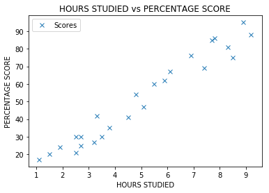

```python
#'Hours studied' is plotted on the x-axis
#'Percentage score' is plotted on the y-axis
data.plot(x='Hours', y='Scores', style='x')
plt.title('HOURS STUDIED vs PERCENTAGE SCORE')
plt.xlabel('HOURS STUDIED')
plt.ylabel('PERCENTAGE SCORE')
plt.show()
```

The above graph clearly depicts a positive linear relation between the two variables.

### Data preprocessing

```python
X = data.iloc[:, :-1].values
Y = data.iloc[:, 1].values
```

```python
#Splitting the dataset into training and testing sets
#This is achieved using the train_test_split() method.
X_train, X_test, Y_train, Y_test = train_test_split(X, Y,
                            test_size=0.2, random_state=0)
```

```python
#Display X_train, X_test, Y_train, Y_test
print(X_train)
print(Y_train)
print(X_test)
print(Y_test)
```

```
[[3.8]
 [1.9]
 [7.8]
 [6.9]
 [1.1]
 [5.1]
 [7.7]
 [3.3]
 [8.3]
 [9.2]
 [6.1]
 [3.5]
 [2.7]
 [5.5]
 [2.7]
 [8.5]
 [2.5]
 [4.8]
 [8.9]
 [4.5]]
[35 24 86 76 17 47 85 42 81 88 67 30 25 60 30 75 21 54 95 41]
[[1.5]
 [3.2]
 [7.4]
 [2.5]
 [5.9]]
[20 27 69 30 62]
```

### Training the model

```python
Lin_reg = LinearRegression()
Lin_reg.fit(X_train, Y_train)
print("Training complete.")
```

```
Training complete.
```

### Plotting the regression line

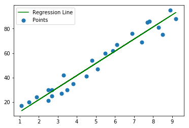

```python
line = Lin_reg.coef_*X+Lin_reg.intercept_
plt.scatter(X, Y, s=50, label='Points')
plt.plot(X, line, color='g', label='Regression Line')
plt.legend()
plt.show()
```

### Making predictions

```python
#Printing the test data
print(X_test)
```

```
[[1.5]
 [3.2]
 [7.4]
 [2.5]
 [5.9]]
```

```python
#Predicting the scores using the regression model
Y_pred = Lin_reg.predict(X_test)
```

### Comparison of the Predicted result with the Actual result

```python
df = pd.DataFrame({'Actual': Y_test, 'Predicted': Y_pred})
df.head()
```

|  | Actual | Predicted |
| --- | --- | --- |
| 0 | 20 | 16.884145 |
| 1 | 27 | 33.732261 |
| 2 | 69 | 75.357018 |
| 3 | 30 | 26.794801 |
| 4 | 62 | 60.491033 |

### Predicting the score of a student who studies 9.25 hours a day (As per the question given)

```python
hours = 9.25
own_pred = Lin_reg.predict(hours)
print("No of Study Hours = {}".format(hours))
print("Predicted Score = {}".format(own_pred[0]))
```

```
No of Study Hours = 9.25
Predicted Score = 93.69173248737538
```

### Evaluating the model

```python
#Printing the Mean Absolute Error
print('Mean Absolute Error:', metrics.mean_absolute_error(Y_test, Y_pred))
```

```
Mean Absolute Error: 4.183859899002975
```

```python
#Printing the Mean Squared Error
print('Mean Squared Error:', metrics.mean_squared_error(Y_test, Y_pred))
```

```
Mean Squared Error: 21.5987693072174
```

### Conclusion

In this task, we have successfully predicted the percentage of marks a student is expected to score based upon the number of study hours. We see that it is a positive linear relation between the two variables and the linear regression line has been plotted for the same.

A student who studies for 9.25 hours a day is expected to score 93.69% as per the above analysis.

The performance of the algorithm is evaluated. The Mean Absolute Error is 4.18. The Mean Squared Error is 21.59.